# Investigating Biomarkers Associated with Cytomegalovirus Short Term Post Heart Transplant

End of Co-op Assignment

Author

Rithika Nair, Linda Lapp

Published

August 1, 2024

## 1 Introduction

Heart transplant surgery is a life-saving treatment for patients with heart failure. In heart transplant surgery, one of the major negative outcomes is acute rejection. To prevent and treat rejections, patients are administered with maximal tolerable doses of immunosuppressive drugs. However, excessive immunosuppression can cause severe complications, such as infections like the reactivation of cytomegalovirus (CMV). CMV is a herpes virus that is commonly found in the adult human population. It presents as asymptomatic or mild flu-like symptoms in healthy adults but can have serious implications, such as pneumonia and gastrointestinal diseases in immunocompromised patients. It can reactivate in about 20% of transplant patients [1] and is influenced by numerous factors such as the transplanted organ, the immune system of the transplant recipient, the immunosuppression drug levels [2]. Much of the existing literature focuses on the the detection of CMV antibodies in the donor and recipient to predict CMV post-transplant. There is limited research investigating other factors that contribute to reactivation of CMV post-transplant. Our goal is to assess how a common immunosuppressant tacrolimus and molecular biomarkers are associated with the treatment of CMV, short-term post-transplant. This study aims to assess how tacrolimus, a common immunosuppressant, and molecular biomarker are associated with the treatment of CMV, short-term post-transplant.

## 2 Methods

### 2.1 Data source and sample selection

The Biomarkers in Transplantation (BiT) program is a prospective, observational study conducted across multiple transplantation sites in Canada. Adult heart-transplant patients present in the outpatient, pretransplant clinic during a routine visit or in inpatient cardiac units before the transplant surgery were enrolled. Recipients with multiple or different solid organ transplants, were HIV positive or received orgain from HIV-positive donors were excluded [3]. This study uses the data collected from recipients enrolled in the BiT program from 2018 to 2020 at St. Paul’s Hospital in Vancouver, BC.

Blood samples were obtained from these patients at 0.5, 1, 1.5, 2, 3, 4, 5, 6, 7, 8, 10, 12 and 24 weeks post-transplantation and then every 6 months until the third year post-transplant. Clinical and laboratory data was also collected from these patients at different time points [3]. For this study, samples and data collected between 0 to 180 days post-transplant are included. The samples are then time matched the clinical and laboratory data such that for each sample, clinical and laboratory data is recorded within 1 day of each other.

Transcriptomic profiling was performed on the blood samples using two assays: TGS assay and HEARTBiT assay. The TGS assay is 36-gene biomarker panel that measures the gene expression for 9 T conventional-marker and 24 T regulatory-marker genes and 3 housekeeping genes. The HEARTBiT assay is a blood-based profiling assay that computes a score which is then used to identify heart transplant patients at risk for ACR. This 12-gene panel measures the gene expression for 3 housekeeping genes and 9 genes used to compute the HEARTBiT score.[4]

### 2.2 Data processing and statistical analyses

#### 2.2.1 Linear Regression Analysis

All analyses were conducted in the R environment. To understand the association between tacrolimus and CMV treatment, we initially assessed two relationships: one between tacrolimus dosing and CMV treatment and another between tacrolimus concentration and CMV treatment. Both of these analyses were performed using a linear model while adjusting for age, sex and time post-transplant. The significance level was set to 5%.

The association between tacrolimus and CMV treatment is further assessed under two different conditions. In the first condition, we account for the patients’ overall rejection status indicating the severity of the patient’s rejection post-transplant, if any. This is determined by looking at the histopathologic results, following the ISHLT guidelines (0R = no rejection, 1R = mild rejection, ≥ 2R = moderate to severe rejection), of all the samples from a patient. If a patient has at least one 2R graded sample, they are classified as moderate rejectors. If a patient has at least one 1R graded sample and no 2R sample, they are classified as mild rejectors. If a patient only has 0R graded samples and no 2R or 1R sample, they are classified as never rejecting. The relationships between tacrolimus concentration and CMV treatment and between tacrolimus dosing and CMV treatment are assessed within each of these groups using a linear model while adjusting for age, sex and time post-transplant at a 5% significance level.

In the second condition, we account for the patients’ renal dysfunction period if the patient had a renal dysfunction at any point pre or post-transplant. This is determined by looking at the patients’ pre-transplant comorbidities recorded in the clinical data and the estimated glomerular filtration rate (eGFR) results recorded post-transplant. The eGFR test is used to determine the level of kidney function such that the patient has normal renal function if eGFR result ≥ 90 mL/min and renal dysfunction if eGFR result < 90 mL/min. If a patient has renal dysfunction both pre- and post-transplant, then they are classified into the “Always” group. If a patient has renal dysfunction only pre-transplant, then they are classified into the “Pre-TX but managed” group. If a patient has renal dysfunction only post-transplant, then they are classified into the “New” group. If a patient does not have renal dysfunction neither pre- nor post-transplant, then they are classified into the “Never” group. The relationships between tacrolimus concentration and CMV treatment and between tacrolimus dosing and CMV treatment are assessed within each of these groups using a linear model while adjusting for age, sex and time post-transplant at a 5% significance level.

#### 2.2.2 Differential Gene Expression Analysis

To understand molecular biomarker associated with CMV treatment, gene expression is compared between samples from patients who received CMV treatment (i.e., treated samples) and samples from patients who did not received CMV treatment (i.e., untreated samples).

Raw transcript counts from the TGS and HEARTBiT assays were normalized sequentially. First, the samples were normalized to the geometric mean of 6 internal positive control probes. The resulting counts were then normalized to geometric mean nean of the housekeeping genes (RPL23A, HNRPA1, and UFC1 for TGS assay, ACTB for HEARTBiT assay) across all samples [[4]][5].

The normalized gene expression data is divided into two subsets. The first subset consisted of data from treated samples collected prior to the first CMV treatment and data from all untreated samples. The second subset consisted of data from treated samples collected during CMV treatment and data from all untreated samples. Differential gene expression analysis is performed on the normalized gene expression data from the two assays, using the linear models for microarray data (limma) package in R. The false discovery rate is set to 10%.

## 3 Results

| label | levels | Not treated | Treated | Total | p |
| --- | --- | --- | --- | --- | --- |
| Total N (%) |  | 26 (65.0) | 14 (35.0) | 40 |  |
| Age | Median (IQR) | 58.5 (54.0 to 63.0) | 64.0 (51.2 to 67.5) | 60.0 (53.2 to 65.2) | 0.227 |
| Sex | F | 6 (23.1) | 7 (50.0) | 13 (32.5) | 0.155 |
|  | M | 20 (76.9) | 7 (50.0) | 27 (67.5) |  |
| Renal Dysfunction Period | Always | 9 (34.6) | 7 (50.0) | 16 (40.0) | 0.268 |
|  | Pre Tx but Managed | 6 (23.1) | 4 (28.6) | 10 (25.0) |  |
|  | New | 2 (7.7) | 2 (14.3) | 4 (10.0) |  |
|  | Never | 9 (34.6) | 1 (7.1) | 10 (25.0) |  |
| Overall ACR Status | Never rejecting | 1 (3.8) | 1 (7.1) | 2 (5.0) | 0.512 |
|  | Mild rejector | 18 (69.2) | 11 (78.6) | 29 (72.5) |  |
|  | Moderate rejector | 7 (26.9) | 2 (14.3) | 9 (22.5) |  |

Table 1: Demographic and clinical data are shown for patients treated and not treated for CMV. Distribution of age, sex, renal dysfunction period and overall ACR status does not significantly differ between treated and untreated patients.

| label | levels | Not treated | Treated | Total | p |
| --- | --- | --- | --- | --- | --- |
| Total N (%) |  | 195 (65.4) | 103 (34.6) | 298 |  |
| Age | Median (IQR) | 60.0 (54.0 to 63.0) | 65.0 (50.0 to 68.0) | 61.0 (54.0 to 66.0) | 0.005 |
| Sex | F | 44 (22.6) | 47 (45.6) | 91 (30.5) | <0.001 |
|  | M | 151 (77.4) | 56 (54.4) | 207 (69.5) |  |
| Time Post-transplant (days) | Median (IQR) | 61.0 (26.0 to 109.0) | 67.0 (28.0 to 118.0) | 62.5 (27.0 to 112.0) | 0.424 |
| Tacrolimus Concentration (µg/L) | Median (IQR) | 9.2 (8.1 to 11.6) | 9.6 (7.9 to 11.2) | 9.5 (8.1 to 11.4) | 0.994 |
| Tacrolimus Total Daily Dose (mg) | Median (IQR) | 6.0 (4.0 to 10.0) | 7.0 (4.0 to 10.0) | 6.0 (4.0 to 10.0) | 0.520 |
| Renal Dysfunction Period | Always | 54 (27.7) | 53 (51.5) | 107 (35.9) | <0.001 |
|  | Pre Tx but Managed | 49 (25.1) | 30 (29.1) | 79 (26.5) |  |
|  | New | 12 (6.2) | 11 (10.7) | 23 (7.7) |  |
|  | Never | 80 (41.0) | 9 (8.7) | 89 (29.9) |  |
| Overall ACR Status | Never rejecting | 6 (3.1) | 3 (2.9) | 9 (3.0) | 0.454 |
|  | Mild rejector | 136 (69.7) | 79 (76.7) | 215 (72.1) |  |
|  | Moderate rejector | 53 (27.2) | 21 (20.4) | 74 (24.8) |  |

Table 2: Demographic and clinical data are shown for samples treated and not treated for CMV. Distribution of age, sex and renal dysfunction period significantly differs between treated and untreated samples at a 5% significance level. Time post-transplant, tacrolimus concentration, tacrolimus dose and overall ACR status does not significantly differ between treated and untreated samples

### 3.1 Association between Tacrolimus Dose and CMV Treatment

In our initial analysis between tacrolimus dosing and CMV treatment, there is no significant association between the two variables when adjusting for age, sex and time since transplant *(p = 0.083)* as shown in Table 3 and Figure 1 (a).

|  | Estimate | Std. Error | t value | p.value |
| --- | --- | --- | --- | --- |
| (Intercept) | 3.344 | 1.086 | 3.080 | 0.0023 |
| CMV_treatment_statusTreated | -0.767 | 0.441 | -1.738 | 0.0832 |
| Age | 0.118 | 0.019 | 6.243 | < 0.001 |
| SexM | -2.035 | 0.469 | -4.341 | < 0.001 |
| Days_Since_HTx | -0.020 | 0.004 | -4.879 | < 0.001 |

Table 3: A linear model is applied to assess the correlation between tacrolimus dosing and CMV treatment age, sex and time since transplant as co-variates. CMV treatment status is not significantly correlated with tacrolimus dosing.

| term | estimate | std.error | statistic | p.value |
| --- | --- | --- | --- | --- |
| **Never rejecting** |  |  |  |  |
| (Intercept) | 5.792 | 2.747 | 2.109 | 0.0795 |
| CMV_treatment_statusTreated | 1.763 | 2.750 | 0.641 | 0.5451 |
| Age |  |  |  |  |
| SexM |  |  |  |  |
| Days_Since_HTx | -0.020 | 0.030 | -0.682 | 0.5204 |
| **Mild rejector** |  |  |  |  |
| (Intercept) | 7.167 | 1.417 | 5.059 | < 0.001 |
| CMV_treatment_statusTreated | -0.387 | 0.547 | -0.708 | 0.4799 |
| Age | 0.058 | 0.024 | 2.433 | 0.0158 |
| SexM | -2.456 | 0.567 | -4.334 | < 0.001 |
| Days_Since_HTx | -0.017 | 0.005 | -3.311 | 0.0011 |
| **Moderate rejector** |  |  |  |  |
| (Intercept) | -2.536 | 1.262 | -2.009 | 0.0485 |
| CMV_treatment_statusTreated | -1.351 | 0.546 | -2.474 | 0.0158 |
| Age | 0.226 | 0.025 | 9.205 | < 0.001 |
| SexM | -2.153 | 0.654 | -3.290 | 0.0016 |
| Days_Since_HTx | -0.029 | 0.005 | -6.037 | < 0.001 |

Table 4: The samples are divided based on the overall ACR status of the patient and a linear model is applied to each group to assess the correlation between tacrolimus dosing and CMV treatment age, sex and time since transplant as co-variates. CMV treatment status is associated with tacrolimus dosing in those who have at least one 2R sample i.e. moderate rejectors. The variables are not associated in any other groups.

| term | estimate | std.error | statistic | p.value |
| --- | --- | --- | --- | --- |
| **Always** |  |  |  |  |
| (Intercept) | 15.461 | 2.757 | 5.608 | < 0.001 |
| CMV_treatment_statusTreated | -0.535 | 0.678 | -0.789 | 0.4319 |
| Age | -0.056 | 0.043 | -1.286 | 0.2014 |
| SexM | -4.082 | 0.796 | -5.129 | < 0.001 |
| Days_Since_HTx | -0.014 | 0.007 | -1.951 | 0.0538 |
| **Pre Tx but Managed** |  |  |  |  |
| (Intercept) | -1.494 | 2.046 | -0.730 | 0.4675 |
| CMV_treatment_statusTreated | -0.806 | 0.713 | -1.131 | 0.2617 |
| Age | 0.190 | 0.039 | 4.874 | < 0.001 |
| SexM | -2.406 | 0.739 | -3.256 | 0.0017 |
| Days_Since_HTx | -0.021 | 0.006 | -3.322 | 0.0014 |
| **New** |  |  |  |  |
| (Intercept) | 1.337 | 4.842 | 0.276 | 0.7856 |
| CMV_treatment_statusTreated | -1.161 | 1.108 | -1.048 | 0.3087 |
| Age | 0.184 | 0.088 | 2.087 | 0.0514 |
| SexM | -5.100 | 1.397 | -3.651 | 0.0018 |
| Days_Since_HTx | -0.034 | 0.010 | -3.250 | 0.0044 |
| **Never** |  |  |  |  |
| (Intercept) | 0.707 | 1.520 | 0.465 | 0.6432 |
| CMV_treatment_statusTreated | 6.016 | 1.668 | 3.606 | < 0.001 |
| Age | 0.102 | 0.029 | 3.550 | < 0.001 |
| SexM | 2.617 | 1.465 | 1.786 | 0.0777 |
| Days_Since_HTx | -0.024 | 0.007 | -3.338 | 0.0013 |

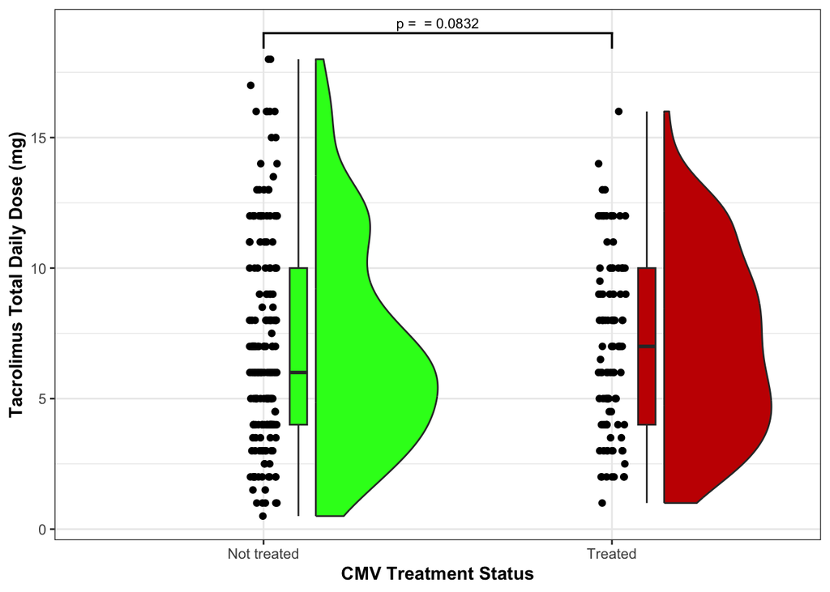

(a) Rain plot showing the distribution of tacrolimus dose between treated and untreated samples.

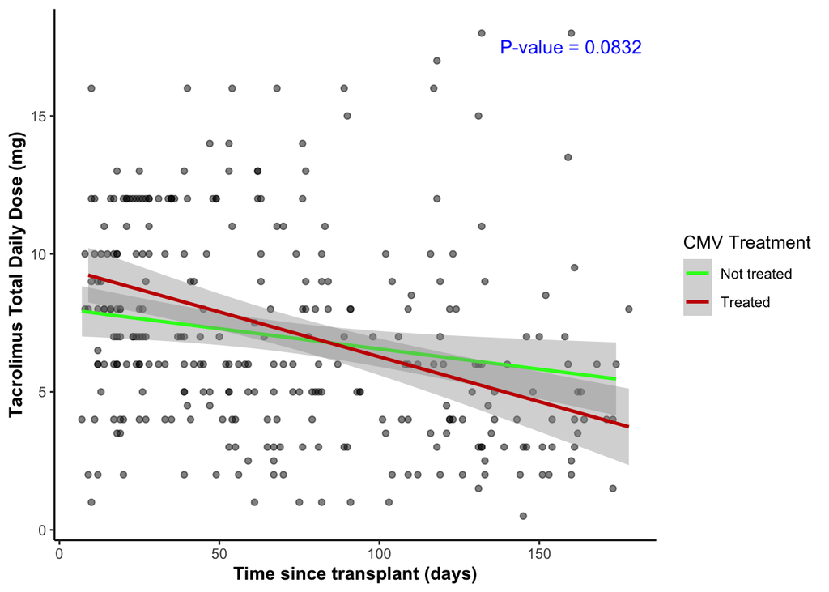

(b) Scatter plot shows the distribution of tacrolimus dose over time, post-transplant for all samples. Regression lines, calculated using a linear model, are plotted for treated and not treated samples. The grey bands depict the confidence intervals.

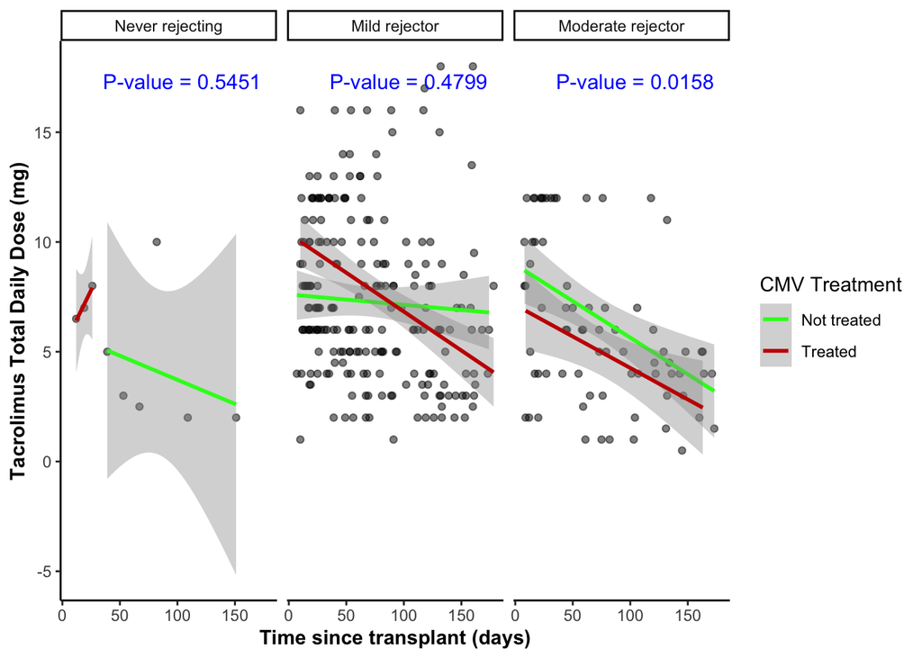

(c) Scatter plots show the distribution of tacrolimus dose over time, post-transplant, faceted by the overall rejection status. Regression lines, calculated using a linear model, are plotted for treated and not treated samples in each group. The grey bands depict the confidence intervals.

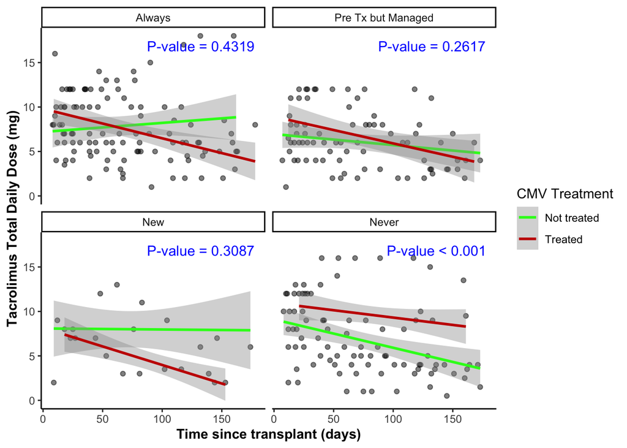

(d) Scatter plots show the distribution of tacrolimus dose over time, post-transplant, faceted by renal dysfunction period. Regression lines, calculated using a linear model, are plotted for treated and not treated samples in each group. The grey bands depict the confidence intervals

Figure 1: Results from the linear models assessing the relationship between tacrolimus dose and CMV treatment.

### 3.2 Association between Tacrolimus Concentration and CMV Treatment

|  | Estimate | Std. Error | t value | p.value |
| --- | --- | --- | --- | --- |
| (Intercept) | 12.163 | 0.963 | 12.635 | < 0.001 |
| CMV_treatment_statusTreated | 0.456 | 0.391 | 1.165 | 0.245 |
| Age | -0.039 | 0.017 | -2.343 | 0.0198 |
| SexM | 0.801 | 0.416 | 1.928 | 0.0549 |
| Days_Since_HTx | -0.011 | 0.004 | -2.931 | 0.0036 |

Table 6: A Linear model is applied to assess the correlation between tacrolimus concentration and CMV treatment with age, sex and time since transplant as co-variates. CMV treatment status is not significantly correlated with tacrolimus concentration.

| term | estimate | std.error | statistic | p.value |
| --- | --- | --- | --- | --- |
| **Never rejecting** |  |  |  |  |
| (Intercept) | 14.928 | 0.405 | 36.821 | < 0.001 |
| CMV_treatment_statusTreated | -5.713 | 0.406 | -14.078 | < 0.001 |
| Age |  |  |  |  |
| SexM |  |  |  |  |
| Days_Since_HTx | -0.036 | 0.004 | -8.102 | < 0.001 |
| **Mild rejector** |  |  |  |  |
| (Intercept) | 11.493 | 1.185 | 9.702 | < 0.001 |
| CMV_treatment_statusTreated | 0.763 | 0.457 | 1.669 | 0.0967 |
| Age | -0.039 | 0.020 | -1.984 | 0.0485 |
| SexM | 1.218 | 0.474 | 2.570 | 0.0109 |
| Days_Since_HTx | -0.010 | 0.004 | -2.215 | 0.0279 |
| **Moderate rejector** |  |  |  |  |
| (Intercept) | 12.018 | 1.912 | 6.285 | < 0.001 |
| CMV_treatment_statusTreated | 0.198 | 0.827 | 0.239 | 0.8118 |
| Age | 0.000 | 0.037 | 0.010 | 0.9917 |
| SexM | -1.081 | 0.991 | -1.091 | 0.2791 |
| Days_Since_HTx | -0.015 | 0.007 | -2.067 | 0.0425 |

Table 7: The samples are divided based on the overall ACR status of the patient and a linear model is applied to each group to assess the correlation between tacrolimus concentration and CMV treatment age, sex and time since transplant as co-variates. CMV treatment status is associated with tacrolimus concentration in those who have never had a 1R or 2R samples. The variables are not associated in any other groups.

In the renal dysfunction period condition, no significant difference is observed between concentration and CMV in any of the groups. This indicates that renal dysfunction does not affect the tacrolimus concentration levels in the blood between patients who were treated and not treated for CMV, as shown below in Table 8 and Figure 2 (d).

| term | estimate | std.error | statistic | p.value |
| --- | --- | --- | --- | --- |
| **Always** |  |  |  |  |
| (Intercept) | 6.261 | 2.624 | 2.386 | 0.0189 |
| CMV_treatment_statusTreated | 0.470 | 0.646 | 0.728 | 0.4684 |
| Age | 0.026 | 0.041 | 0.643 | 0.5217 |
| SexM | 2.300 | 0.758 | 3.036 | 0.003 |
| Days_Since_HTx | -0.010 | 0.007 | -1.540 | 0.1266 |
| **Pre Tx but Managed** |  |  |  |  |
| (Intercept) | 11.554 | 2.154 | 5.364 | < 0.001 |
| CMV_treatment_statusTreated | 0.280 | 0.751 | 0.373 | 0.7101 |
| Age | -0.014 | 0.041 | -0.336 | 0.738 |
| SexM | 0.861 | 0.778 | 1.108 | 0.2716 |
| Days_Since_HTx | -0.011 | 0.007 | -1.723 | 0.089 |
| **New** |  |  |  |  |
| (Intercept) | 6.383 | 6.515 | 0.980 | 0.3402 |
| CMV_treatment_statusTreated | 1.594 | 1.491 | 1.069 | 0.2991 |
| Age | 0.086 | 0.119 | 0.724 | 0.4781 |
| SexM | -1.790 | 1.879 | -0.953 | 0.3535 |
| Days_Since_HTx | -0.013 | 0.014 | -0.965 | 0.3475 |
| **Never** |  |  |  |  |
| (Intercept) | 13.116 | 1.304 | 10.061 | < 0.001 |
| CMV_treatment_statusTreated | 0.925 | 1.431 | 0.646 | 0.5197 |
| Age | -0.056 | 0.025 | -2.292 | 0.0244 |
| SexM | 0.958 | 1.257 | 0.762 | 0.4482 |
| Days_Since_HTx | -0.014 | 0.006 | -2.197 | 0.0308 |

Table 8: The samples are divided based on the renal dysfunction status of the patient and a linear model is applied to each group to assess the correlation between tacrolimus concentration and CMV treatment age, sex and time since transplant as co-variates. CMV treatment status is not associated with tacrolimus concentration in any of the renal dysfunction period groups.

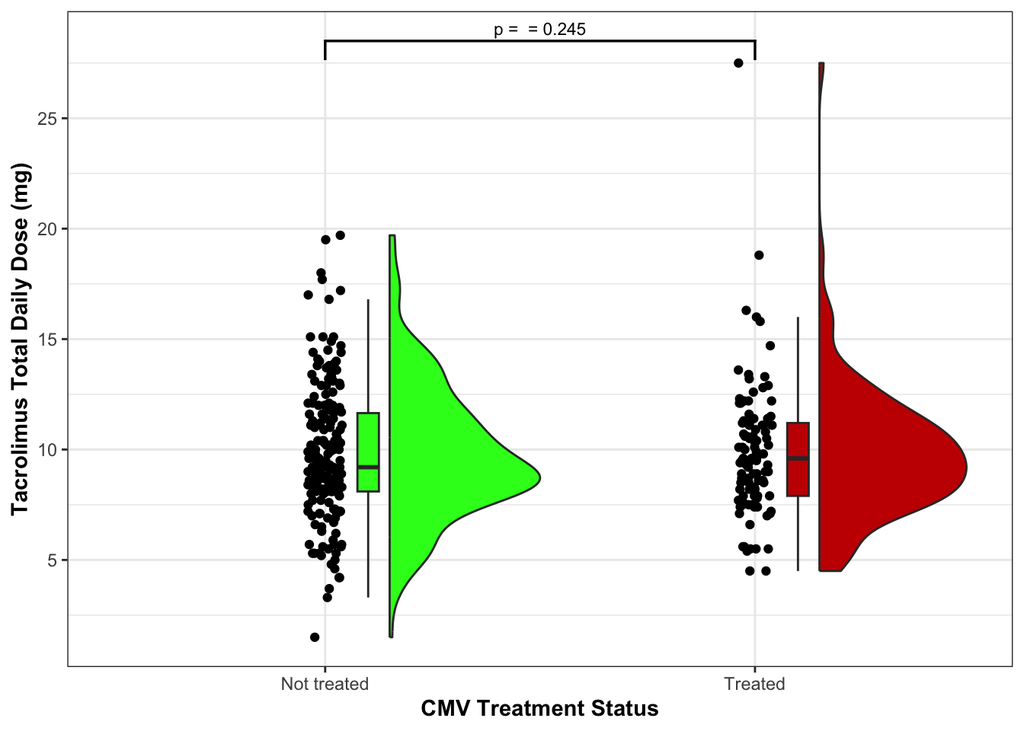

(a) Rain plot showing the distribution of tacrolimus concentration between treated and untreated samples.

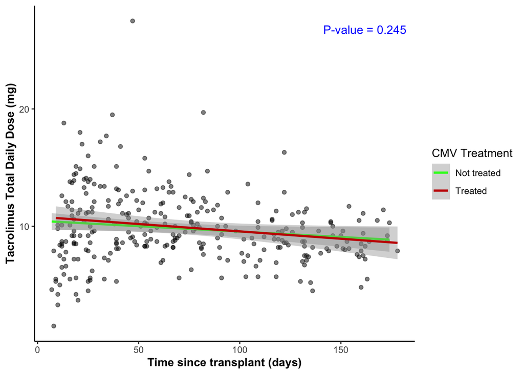

(b) Scatter plot shows the distribution of tacrolimus concentration over time, post-transplant for all samples. Regression lines, calculated using a linear model, are plotted for treated and not treated samples. The grey bands depict the confidence intervals.

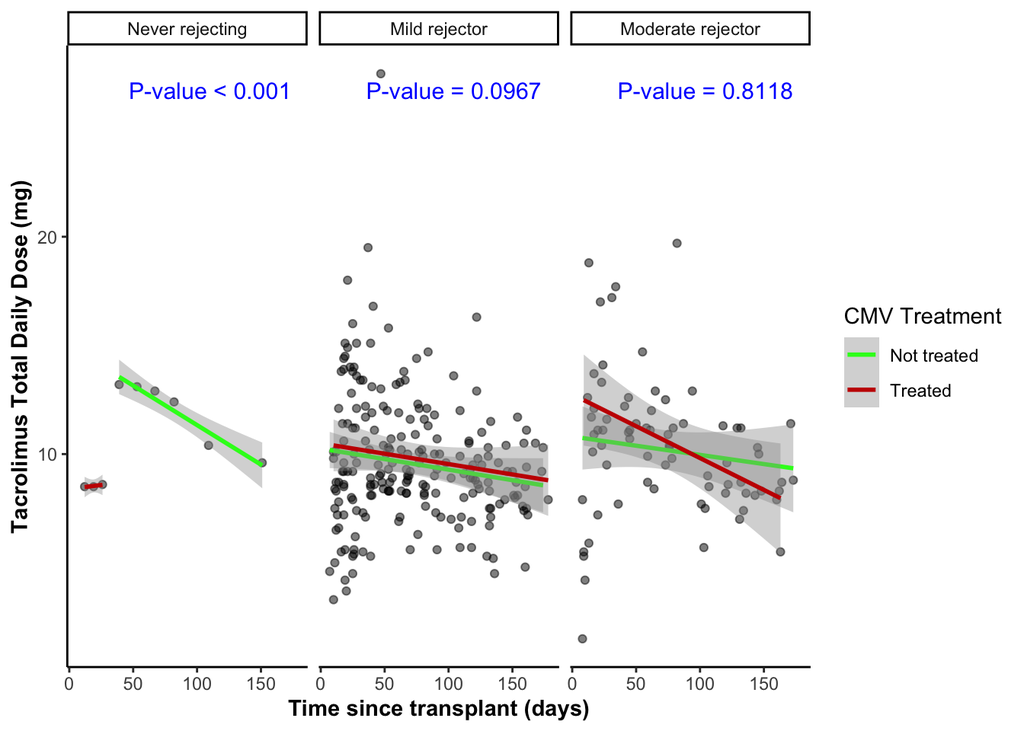

(c) Scatter plots show the distribution of tacrolimus concentration over time, post-transplant, faceted by the overall rejection status. Regression lines, calculated using a linear model, are plotted for treated and not treated samples in each group. The grey bands depict the confidence intervals.

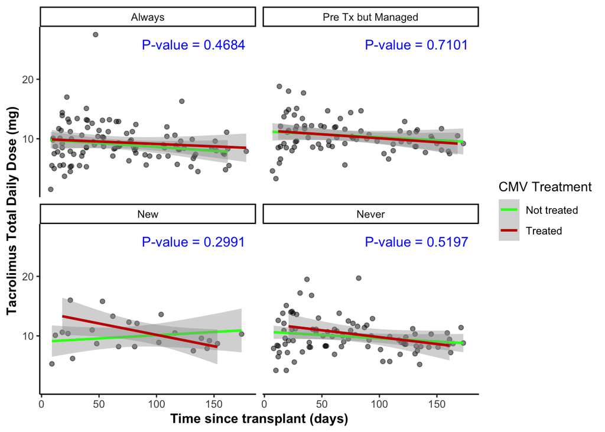

(d) Scatter plots show the distribution of tacrolimus concentration over time, post-transplant, faceted by renal dysfunction period. Regression lines, calculated using a linear model, are plotted for treated and not treated samples in each group. The grey bands depict the confidence intervals

Figure 2: Results from the linear models assessing the relationship between tacrolimus concentration and CMV treatment.

### 3.3 Differential Gene Expression Analysis

Table 9

| label | levels | Not treated | Treated | Total | p |
| --- | --- | --- | --- | --- | --- |
| Total N (%) |  | 108 (57.8) | 79 (42.2) | 187 |  |
| Age | Median (IQR) | 58.5 (48.0 to 63.0) | 63.0 (54.5 to 66.0) | 60.0 (51.0 to 66.0) | 0.001 |
| Sex | F | 36 (33.3) | 26 (32.9) | 62 (33.2) | 1.000 |
|  | M | 72 (66.7) | 53 (67.1) | 125 (66.8) |  |
| Time Post-transplant (days) | Median (IQR) | 61.5 (27.0 to 129.5) | 70.0 (25.0 to 139.0) | 63.0 (26.0 to 132.0) | 0.768 |

Table 10: Demographic and clinical data are shown for samples treated and not treated for CMV in the gene expression data for the TGS assay. Distribution of age significantly differs between treated and untreated samples at a 5% significance level. Time post-transplant and sex do not significantly differ between treated and untreated samples

| label | levels | Not treated | Treated | Total | p |
| --- | --- | --- | --- | --- | --- |
| Total N (%) |  | 241 (61.0) | 154 (39.0) | 395 |  |
| Age | Median (IQR) | 59.0 (51.0 to 63.0) | 63.0 (50.0 to 66.0) | 60.0 (51.0 to 65.0) | 0.003 |
| Sex | F | 66 (27.4) | 59 (38.3) | 125 (31.6) | 0.027 |
|  | M | 175 (72.6) | 95 (61.7) | 270 (68.4) |  |
| Time Post-transplant (days) | Median (IQR) | 75.0 (33.0 to 143.0) | 67.0 (28.0 to 133.8) | 73.0 (30.0 to 136.0) | 0.396 |

Table 11: Demographic and clinical data are shown for samples treated and not treated for CMV in the gene expression data for the HEARTBiT assay. Distribution of age and sex significantly differs between treated and untreated samples at a 5% significance level. Time post-transplant does not significantly differ between treated and untreated samples

#### 3.3.1 TGS Assay

Through gene expression analysis, we found that in patients who received CMV treatment, four genes higher expressed in T-conventional cells *(ANK3, DACT1, HDGFRP3, LPIN2)* and one gene higher expressed in T-regulatory cells *(FOXP3)* are significantly upregulated, and two genes higher expressed in T-regulatory cells *(TNFRSF9, ZNK532)* are significantly downregulated before the CMV treatment (Table 12 (a), Figure 3 (a)). In patients who received CMV treatment, two genes higher expressed in T-conventional cells *(ANK3, HDGFRP3)* are significantly upregulated and five genes higher expressed in T-regulatory cells *(CSF2RB, IL1R1, IL1R2, TNFRSF9, ZNK532)* are significantly downregulated during the CMV treatment (Table 12 (b), Figure 3 (b)).

| Gene | T_cell_Type | logFC |
| --- | --- | --- |
| TNFRSF9 | Treg | -1.283 |
| ZNF532 | Treg | -0.921 |
| HDGFRP3 | Tconv | 0.627 |
| FOXP3 | Treg | 0.731 |
| ANK3 | Tconv | 0.884 |
| LPIN2 | Tconv | 0.903 |
| DACT1 | Tconv | 1.542 |

(a) Log fold changes for the differentially expressed genes for samples taken before CMV treatment.

| Gene | T_cell_Type | logFC |
| --- | --- | --- |
| IL1R2 | Treg | -2.377 |
| IL1R1 | Treg | -1.933 |
| TNFRSF9 | Treg | -1.469 |
| CSF2RB | Treg | -1.321 |
| ZNF532 | Treg | -0.646 |
| HDGFRP3 | Tconv | 0.552 |
| ANK3 | Tconv | 1.006 |

(b) Log fold changes for the differentially expressed genes for samples taken during CMV treatment.

Table 12: Log fold changes of the differentially expressed genes in the TGS assay at a 10% false discovery rate. Genes with LogFC values > 0 are upregulated and LogFC values < 0 are downregulated.

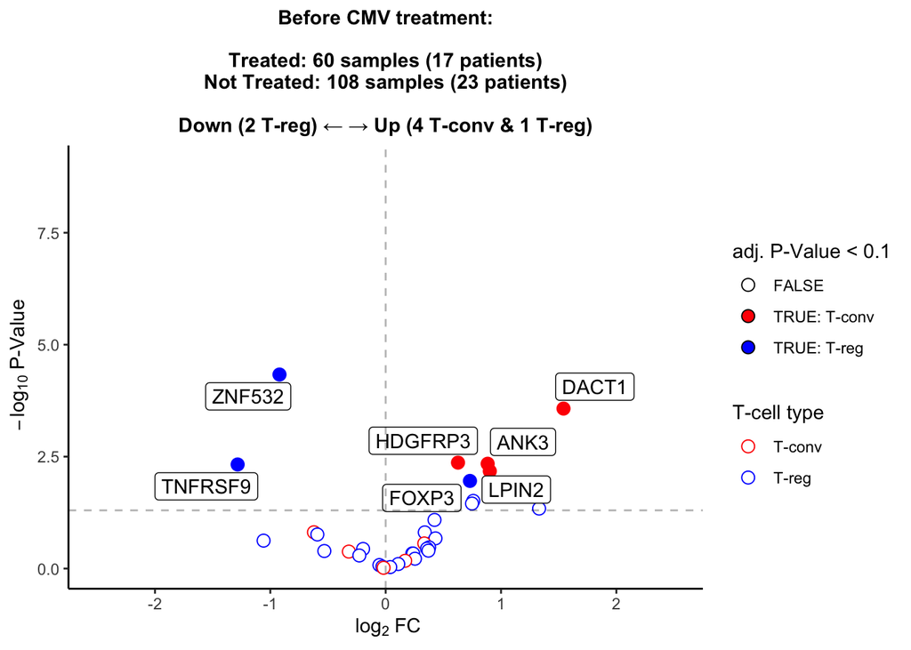

(a) Differential gene expression analysis between samples taken before treatment from the treated group and all the samples from the untreated group

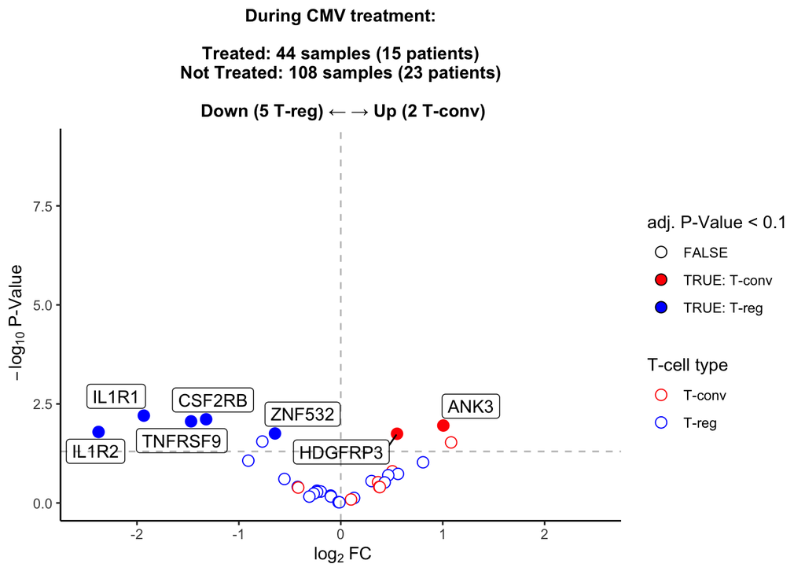

(b) Differential gene expression analysis between samples taken during treatmentfrom the treated group and all the samples from the untreated group

Figure 3: The volcano plots visualizes the differential gene expression results obtained from fitting the limma models. The genes correspond to 33 genes in TGS assay. The horizontal dashed line indicates the threshold for false discovery rate; genes found above this line have a significant difference in gene expression between treated and untreated samples. The x-axis indicates the magnitude of difference in gene expression and the vertical dashed line indicates the threshold; genes to the right of the line are upregulated in treated samples and genes to the left are downregulated in treated samples. Colors of the points indicate the type of T-cell that the gene is found in. Filled circles correspond to the genes with significant differential expression and empty circles correspond to genes with no significant differential expression.

#### 3.3.2 HEARTBiT Assay

Through gene expression analysis, we found that in patients who received CMV treatment, four genes from the assay *(CTSE, HEBP1, IFIT2, VNN1)* are significantly upregulated before the CMV treatment (Table 13 (a), Figure 4 (a)) and one gene *(HEBP1)* is significantly upregulated during the CMV treatment (Table 13 (a), Figure 4 (b)).

| Gene | logFC |
| --- | --- |
| CTSE | 0.682 |
| IFIT2 | 1.016 |
| VNN1 | 1.188 |
| HEBP1 | 1.354 |

(a) Log fold changes for the differentially expressed genes for samples taken before CMV treatment.

| Gene | logFC |
| --- | --- |
| HEBP1 | 1.192 |

(b) Log fold changes for the differentially expressed genes for samples taken during CMV treatment.

Table 13: Log fold changes of the differentially expressed genes in the HEARTBiT assay at a 10% false discovery rate. Genes with LogFC values > 0 are upregulated and LogFC values < 0 are downregulated.

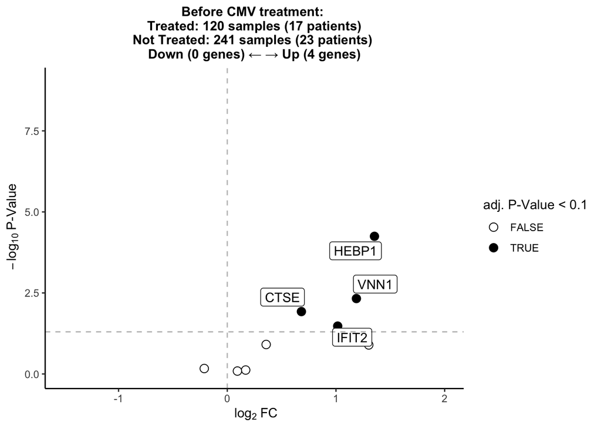

(a) Differential gene expression analysis between samples taken before treatment from the treated group and all the samples from the untreated group

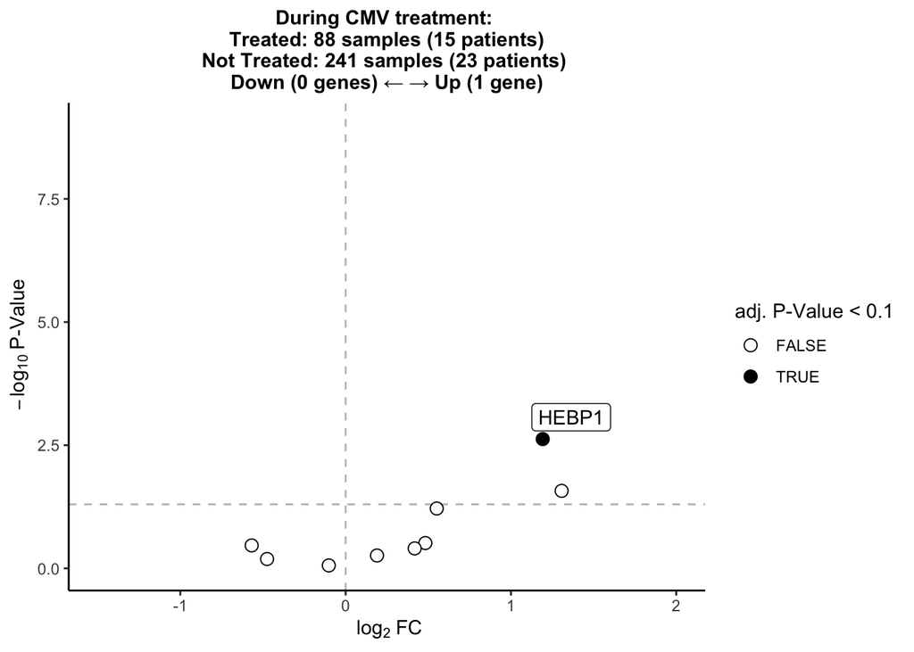

(b) Differential gene expression analysis between samples taken during treatmentfrom the treated group and all the samples from the untreated group

Figure 4: The volcano plots visualizes the differential gene expression results obtained from fitting the limma models. The genes correspond to 9 genes in HEARTBiT assay. The horizontal dashed line indicates the threshold for false discovery rate; genes found above this line have a significant difference in gene expression between treated and untreated samples. The x-axis indicates the magnitude of difference in gene expression and the vertical dashed line indicates the threshold; genes to the right of the line are upregulated in treated samples and genes to the left are downregulated in treated samples. Filled circles correspond to the genes with significant differential expression and empty circles correspond to genes with no significant differential expression.

## 4 Discussion

One of the major limitations of this study is the small sample size. This is a common challenge in the research of heart transplantation due to the rarity of the heart transplantation cases. In British Columbia, between 2018 and 2020, there was an average of 30 heart transplant cases per year and the St. Paul’s Hospital is the only adult heart transplant center in the province [8]. Hence, limited data is available for us to investigate outcomes related to heart transplant. Although we analyze data from blood samples collected at specific time points, not every sample has clinical or laboratory data associated with it since post-transplant follow up care may be done in other medical facilities than our primary site or due to irregular collection of CMV related data. We attempt to overcome this limitation by adjusting for time in all of our analyses however, this limitation may still have impacted our ability to identify significant association between tacrolimus and CMV at a patient-level. This identifies the need for regular monitoring of CMV associated clinical and laboratory data to better understand the onset of CMV in patients post-transplant.

Our primary site, St. Paul’s Hospital, is one of 8 transplant centres in Canada and using patient data from this site is a strength of this study. Since this site has one of the highest number of heart transplant surgeries in the country [9], these findings could apply to the entire Canadian population, and not just those in British Columbia. However, external validation using data from other centres is required. To our knowledge, this is the first study to examine gene expression as a biomarker for CMV short term post transplant. This is another strength of our study as it provides a novel contribution to better diagnostic tools for clinicians to identify patients at risk for CMV.

Future work involves the validation of the TGS assay with more samples and further exploration of differentially expression genes to thoroughly understand their role in identifying patients at risk for CMV. Additionally, we aim to use the significantly associated clinical factors along with the findings from the TGS and HEARTBiT assays to build a predictive model that can be provides the chances of patient developing CMV based on personalized, patient-specific factors.

## 6 References

1.

Azevedo LS, Pierrotti LC, Abdala E, et al (2015) Cytomegalovirus infection in transplant recipients. Clinics 70(7):515–523. https://doi.org/10.6061/clinics/2015(07)09

2.

Bisono-Garcia BS, Yetmar ZA, Nair V, et al (2024) Cytomegalovirus infection in heart transplant recipients: Epidemiology, risk factors, and long-term outcomes from a major transplant center in the united states. JHLT Open 4:100047. https://doi.org/10.1016/j.jhlto.2023.100047

3.

Shannon CP, Hollander Z, Dai DLY, et al (2020) Heartbit: A transcriptomic signature for excluding acute cellular rejection in adult heart allograft patients. Canadian Journal of Cardiology 36(8):1217–1227. https://doi.org/10.1016/j.cjca.2019.11.017

4.

Kim J-YV, Assadian S, Hollander Z, et al (2023) Regulatory t cell biomarkers identify patients at risk of developing acute cellular rejection in the first year following heart transplantation. Transplantation 107(8):1810–1819. https://doi.org/10.1097/tp.0000000000004607

5.

[Gene expression data analysis guidelines](https://nanostring.com/wp-content/uploads/Gene_Expression_Data_Analysis_Guidelines.pdf)

6.

Sikma MA, Maarseveen EM van, Graaf EA van de, et al (2015) Pharmacokinetics and toxicity of tacrolimus early after heart and lung transplantation. American Journal of Transplantation 15(9):2301–2313. https://doi.org/10.1111/ajt.13309

7.

Kim J-YV, Lee B, Koitsopoulos P, et al (2020) Analytical validation of heartbit: A BLOOD-based multiplex gene expression profiling assay for exclusionary diagnosis of acute cellular rejection in heart transplant patients. Clinical Chemistry 66(8):1063–1071. https://doi.org/10.1093/clinchem/hvaa123

8.

[BC transplant](http://www.transplant.bc.ca/Documents/Statistics/2023-BC-Organ-Donation-Transplant-Summary.pdf)

9.

[CIHI](https://www.cihi.ca/en/summary-statistics-on-organ-transplants-wait-lists-and-donors)